# Introduction to Dplyr and Ggplot2

## Inspecting your dataframe

Use the `dim()` function to see how many rows (observations) and columns (variables) there are

```r
dim(df_input)
```

```
## [1] 1025   15
```

## Inspecting your dataframe

Use the `glimpse()` function to see what kinds of variables the dataset contains

```r
glimpse(df_input)
```

```
## Observations: 1,025
## Variables: 15
## $ thalach    <dbl> 168, 155, 125, 161, 106, 122, 140, 145, 144, 116, 125, 136…
## $ exang      <dbl> 0, 1, 1, 0, 0, 0, 0, 1, 0, 1, 0, 1, 0, 1, 1, 0, 0, 1, 0, 0…
## $ slope      <dbl> 2, 0, 0, 2, 1, 1, 0, 1, 2, 1, 1, 1, 2, 1, 1, 2, 2, 1, 2, 2…
## $ sex_symbol <chr> "M", "M", "M", "M", "F", "F", "M", "M", "M", "M", "F", "F"…
## $ ca         <dbl> 2, 0, 0, 1, 3, 0, 3, 1, 0, 2, 0, 0, 0, 3, 0, 0, 1, 1, 0, 0…
## $ chol       <dbl> 212, 203, 174, 203, 294, 248, 318, 289, 249, 286, 149, 341…
## $ sex        <chr> "male", "male", "male", "male", "female", "female", "male"…
## $ thal       <dbl> 3, 3, 3, 3, 2, 2, 1, 3, 3, 2, 2, 3, 2, 3, 0, 2, 2, 3, 2, 2…
## $ restecg    <dbl> 1, 0, 1, 1, 1, 0, 2, 0, 0, 0, 1, 0, 1, 1, 1, 1, 0, 0, 1, 0…
## $ target     <dbl> 0, 0, 0, 0, 0, 1, 0, 0, 0, 0, 1, 0, 1, 0, 0, 1, 1, 0, 1, 1…
## $ trestbps   <dbl> 125, 140, 145, 148, 138, 100, 114, 160, 120, 122, 112, 132…
## $ oldpeak    <dbl> 1.0, 3.1, 2.6, 0.0, 1.9, 1.0, 4.4, 0.8, 0.8, 3.2, 1.6, 3.0…
## $ fbs        <dbl> 0, 1, 0, 0, 1, 0, 0, 0, 0, 0, 0, 1, 0, 0, 1, 0, 0, 0, 0, 1…
## $ cp         <dbl> 0, 0, 0, 0, 0, 0, 0, 0, 0, 0, 0, 0, 1, 0, 0, 1, 2, 0, 1, 2…
## $ age        <dbl> 52, 53, 70, 61, 62, 58, 58, 55, 46, 54, 71, 43, 34, 51, 52…
```

## Basic Data Types in R

R has 6 basic data types -

**character** - `"a"`, `"tidyverse"`

**numeric** - `2`, `11.5`

**integer** - `2L` (the `L` tells R to store this as an integer)

**logical** - `TRUE`, `FALSE`

**complex** - `1+4i`

(**raw**)

You will also come across the **double** datatype. It is the same as **numeric**

**factor**. A **factor** is a collection of *ordered* character variables

## Basic Data Types in R

In addition to the `glimpse()` function, you can use the `class()` function to determine the data type of a specific column

class(df$sex)

```
## [1] "character"
```

## (Re)Introducing `%>%`

The `%>%` operator is a way of “chaining” together strings of commands that make reading your code easy. The following code chunk illustrates how `%>%` works

df_input %>%  
select(sex, trestbps) %>%  
filter(sex == male) %>%  
head()

```
## # A tibble: 6 x 2
##   sex   trestbps
##   <chr>    <dbl>
## 1 male       125
## 2 male       140
## 3 male       145
## 4 male       148
## 5 male       114
## 6 male       160
```

## (Re)Introducing `%>%`

The previous code chunk does the following - it takes you dataset and “pipes” it into `select()`

When you see `%>%`, think “and then”

## (Re)Introducing `%>%`

The alternative to using `%>%` is running the following code

filter(select(df_input, sex, trestbps), sex == male)

Although this is only one line as opposed to three, it’s both more difficult to write and more difficult to read

## Introducing the main dplyr verbs

dplyr is a package that contains a suite of functions that allow you to easily manipulate a dataset

Some of the things you can do are -

- select rows and columns that match specific criteria
- create new variables (columns)
- obtain summary statistics on individual groups within your datsets

The main verbs we will cover are `select()`, `filter()`, `arrange()`, `mutate()`, and `summarise()`. These all combine naturally with `group_by()` which allows you to perform any operation “by group”

## `select()`

The `select()` verb allows you to extract specific columns from your dataset

The most basic `select()` is one where you comma separate a list of columns you want included

For example, if you only want to select the sex and trestbps columns, run the following code chunk

df_input %>%  
select(sex, trestbps) %>%  
head()

```
## # A tibble: 6 x 2
##   sex    trestbps
##   <chr>     <dbl>
## 1 male        125
## 2 male        140
## 3 male        145
## 4 male        148
## 5 female      138
## 6 female      100
```

## `select()`

If you want to select all columns *except* sex, run the following

df_input %>%  
select(-sex) %>%  
head()

```
## # A tibble: 6 x 14
##   thalach exang slope sex_symbol    ca  chol  thal restecg target trestbps
##     <dbl> <dbl> <dbl> <chr>      <dbl> <dbl> <dbl>   <dbl>  <dbl>    <dbl>
## 1     168     0     2 M              2   212     3       1      0      125
## 2     155     1     0 M              0   203     3       0      0      140
## 3     125     1     0 M              0   174     3       1      0      145
## 4     161     0     2 M              1   203     3       1      0      148
## 5     106     0     1 F              3   294     2       1      0      138
## 6     122     0     1 F              0   248     2       0      1      100
## # … with 4 more variables: oldpeak <dbl>, fbs <dbl>, cp <dbl>, age <dbl>
```

## `select()`

Finally, you can provide a range of columns to return two columns and everything in between. For example

df_input %>%  
select(sex:trestbps) %>%  
head(1)

```
## # A tibble: 1 x 5
##   sex    thal restecg target trestbps
##   <chr> <dbl>   <dbl>  <dbl>    <dbl>
## 1 male      3       1      0      125
```

This code selects the following columns -

```
## [1] "sex"      "thal"     "restecg"  "target"   "trestbps"
```

## `filter()`

The `filter()` verb allows you to choose rows based on certain condition(s) and discard everything else

All filters are performed on some logical statement

If a row meets the condition of this statement (i.e. is true) then it gets chosen (or “filtered”). All other rows are discarded

## `filter()`

Filtering can be performed on categorical data

df_input %>%  
filter(sex == male) %>%  
head(3)

```
## # A tibble: 3 x 15
##   thalach exang slope sex_symbol    ca  chol sex    thal restecg target trestbps
##     <dbl> <dbl> <dbl> <chr>      <dbl> <dbl> <chr> <dbl>   <dbl>  <dbl>    <dbl>
## 1     168     0     2 M              2   212 male      3       1      0      125
## 2     155     1     0 M              0   203 male      3       0      0      140
## 3     125     1     0 M              0   174 male      3       1      0      145
## # … with 4 more variables: oldpeak <dbl>, fbs <dbl>, cp <dbl>, age <dbl>
```

Note that `filter()` only applies to rows, and has no effect on columns

## `filter()`

Filtering can also be performed on numerical data

For example, if you wanted to choose trestbps with a value greater than 135, you would run the following.

df_input %>%  
filter(trestbps > 135) %>%  
head(3)

[output not shown]

## `filter()`

To filter on multiple conditions, you can write a sequence of `filter()` commands

df_input %>%  
filter(sex == male) %>%  
filter(trestbps > 135) %>%  
head(3)

[output not shown]

## `filter()`

To avoid writing multiple `filter()` commands, multiple logical statements can be put inside a single `filter()` command, separated by commas

df_input %>%  
filter(sex == male, trestbps > 135) %>%  
head(3)

## `arrange()`

You can use the `arrange()` verb to sort rows

The input for arrange is one or many columns, and `arrange()` sorts the rows in ascending order i.e. from smallest to largest

For example, to sort rows from smallest to largest trestbps, run the following

df_input %>%  
arrange(trestbps) %>%  
head(3)

```
## # A tibble: 3 x 15
##   thalach exang slope sex_symbol    ca  chol sex    thal restecg target trestbps
##     <dbl> <dbl> <dbl> <chr>      <dbl> <dbl> <chr> <dbl>   <dbl>  <dbl>    <dbl>
## 1     179     0     2 F              0   199 fema…     2       1      1       94
## 2     179     0     2 F              0   199 fema…     2       1      1       94
## 3     154     1     2 M              1   227 male      3       1      1       94
## # … with 4 more variables: oldpeak <dbl>, fbs <dbl>, cp <dbl>, age <dbl>
```

## `arrange()`

To reverse this order, use the `desc()` function within `arrange()`

df_input %>% arrange(desc(trestbps)) %>% head(3)

```
## # A tibble: 3 x 15
##   thalach exang slope sex_symbol    ca  chol sex    thal restecg target trestbps
##     <dbl> <dbl> <dbl> <chr>      <dbl> <dbl> <chr> <dbl>   <dbl>  <dbl>    <dbl>
## 1     133     1     0 F              2   288 fema…     3       0      0      200
## 2     133     1     0 F              2   288 fema…     3       0      0      200
## 3     133     1     0 F              2   288 fema…     3       0      0      200
## # … with 4 more variables: oldpeak <dbl>, fbs <dbl>, cp <dbl>, age <dbl>
```

## `mutate()`

The `mutate()` verb, unlike the ones covered so far, creates new variable(s) i.e. new column(s). For example

df_input %>%  
mutate(new_col = sqrt(trestbps)) %>%  
head(1)

```
## # A tibble: 1 x 16
##   thalach exang slope sex_symbol    ca  chol sex    thal restecg target trestbps
##     <dbl> <dbl> <dbl> <chr>      <dbl> <dbl> <chr> <dbl>   <dbl>  <dbl>    <dbl>
## 1     168     0     2 M              2   212 male      3       1      0      125
## # … with 5 more variables: oldpeak <dbl>, fbs <dbl>, cp <dbl>, age <dbl>,
## #   new_col <dbl>
```

The code chunk above takes all the elements of the column trestbps, evaluates the square root of each element, and populates a new column called `new_col` with these results

## `summarise()`

`summarise()` produces a new dataframe that aggregates that values of a column based on a certain condition.

For example, to calculate the mean trestbps, run the following

df_input %>%  
summarise(mean(trestbps))

```
## # A tibble: 1 x 1
##   `mean(trestbps)`
##              <dbl>
## 1             132.
```

## `group_by()`

`group_by()` and `summarise()` can be used in combination to summarise by groups

df_input %>%  
group_by(sex) %>%  
summarise(mean(trestbps))

```
## # A tibble: 2 x 2
##   sex    `mean(trestbps)`
##   <chr>             <dbl>
## 1 female             134.
## 2 male               131.
```

## Saving a new dataset

If you’d like to save the output of your wrangling, you will need to use the `<-` or `->` operators

df_new <- df_input %>%  
group_by(sex) %>%  
summarise(mean(trestbps))

To save `df_new` as a new file (e.g. csv), run the following

write_csv(df_new, “df_new.csv”)

## For more help

Run the following to access the Dplyr vignette

browseVignettes(“dplyr”)

## Basic ggplot2

## Basics of a ggplot code

Below is an example of the most basic form of the ggplot code

ggplot(data) +  
geom(mapping=aes(x, y))

## Basics of a ggplot code

Take a moment to look back at the code you ran previously. You can see that in that code we assigned a dataset and the information we needed to map it to a scatterplot.

## Basics of a ggplot code

ggplot(data = df_input) +  
geom_point(mapping=aes(x = thalach, y = chol))

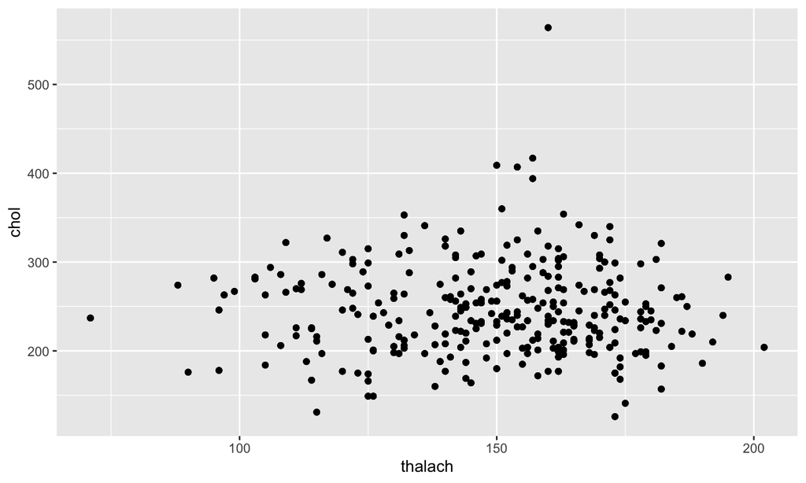

## Basics of a ggplot code

A note on ggplot style: while you can put the `+` at the beginning of the next line, it is generally put at the end of the previous line.

How does this chunk of code differ from the previous chunk?

ggplot(df_input) +  
geom_point(aes(x = thalach, y = chol))

## Geoms

When plotting your data, it is often helpful to take a glimpse at the data you intend to plot to know what kinds of variables you will be working with

```
## Observations: 1,025
## Variables: 15
## $ thalach    <dbl> 168, 155, 125, 161, 106, 122, 140, 145, 144, 116, 125, 136…
## $ exang      <dbl> 0, 1, 1, 0, 0, 0, 0, 1, 0, 1, 0, 1, 0, 1, 1, 0, 0, 1, 0, 0…
## $ slope      <dbl> 2, 0, 0, 2, 1, 1, 0, 1, 2, 1, 1, 1, 2, 1, 1, 2, 2, 1, 2, 2…
## $ sex_symbol <chr> "M", "M", "M", "M", "F", "F", "M", "M", "M", "M", "F", "F"…
## $ ca         <dbl> 2, 0, 0, 1, 3, 0, 3, 1, 0, 2, 0, 0, 0, 3, 0, 0, 1, 1, 0, 0…
## $ chol       <dbl> 212, 203, 174, 203, 294, 248, 318, 289, 249, 286, 149, 341…
## $ sex        <chr> "male", "male", "male", "male", "female", "female", "male"…
## $ thal       <dbl> 3, 3, 3, 3, 2, 2, 1, 3, 3, 2, 2, 3, 2, 3, 0, 2, 2, 3, 2, 2…
## $ restecg    <dbl> 1, 0, 1, 1, 1, 0, 2, 0, 0, 0, 1, 0, 1, 1, 1, 1, 0, 0, 1, 0…
## $ target     <dbl> 0, 0, 0, 0, 0, 1, 0, 0, 0, 0, 1, 0, 1, 0, 0, 1, 1, 0, 1, 1…
## $ trestbps   <dbl> 125, 140, 145, 148, 138, 100, 114, 160, 120, 122, 112, 132…
## $ oldpeak    <dbl> 1.0, 3.1, 2.6, 0.0, 1.9, 1.0, 4.4, 0.8, 0.8, 3.2, 1.6, 3.0…
## $ fbs        <dbl> 0, 1, 0, 0, 1, 0, 0, 0, 0, 0, 0, 1, 0, 0, 1, 0, 0, 0, 0, 1…
## $ cp         <dbl> 0, 0, 0, 0, 0, 0, 0, 0, 0, 0, 0, 0, 1, 0, 0, 1, 2, 0, 1, 2…
## $ age        <dbl> 52, 53, 70, 61, 62, 58, 58, 55, 46, 54, 71, 43, 34, 51, 52…
```

## Geoms

So now that you know your variable types, how do you know what geoms to use?? Use the following resources! * https://rstudio.com/wp-content/uploads/2015/03/ggplot2-cheatsheet.pdf * https://www.data-to-viz.com/

Sometimes you will run into errors indicating more information is needed for a plot or that you do not have the correct variable types. For more in depth information on the geoms, I find the ggplot2 reference page more helpful than the built in help pages * https://ggplot2.tidyverse.org/reference/index.html

## Aesthetics

Everything up to this point gets you a basic graph- but what about colors, shapes and overal style?

There are 5 basic aesthetics you can can change 1. Color- changes the outline color of your datapoints 2. size 3. Shape 4. alpha- changes the transparency of each point 5. fill- changes the fill color of your points

## Global vs Local

In ggplot2, we have the options to set mappings globally or locally. Setting a mapping globally means to set those values in the original ggplot function. Example: Earlier in class you made this graph:

ggplot(df_input) +  
geom_jitter(aes(x=sex_symbol, y=log(thalach)))+ geom_boxplot(aes(x=sex_symbol, y=log(thalach)))

## Global vs Local

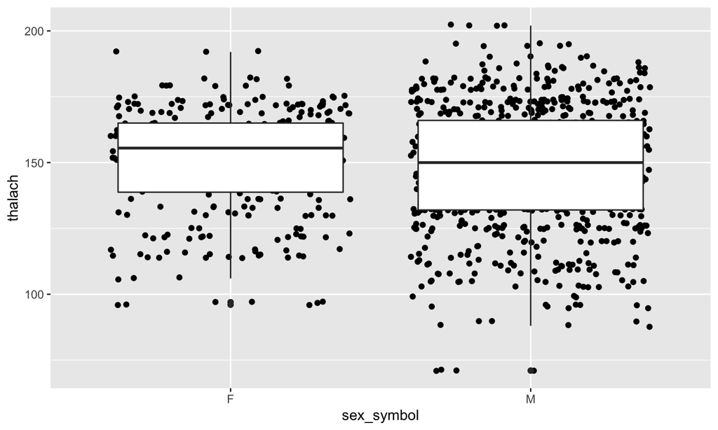

## Global vs Local

However, if we map our x and y values in the ggplot function we find that we generate the same graph  
ggplot(df_input, aes(x=sex_symbol, y=log(thalach)) + geom_jitter() +  
geom_boxplot()

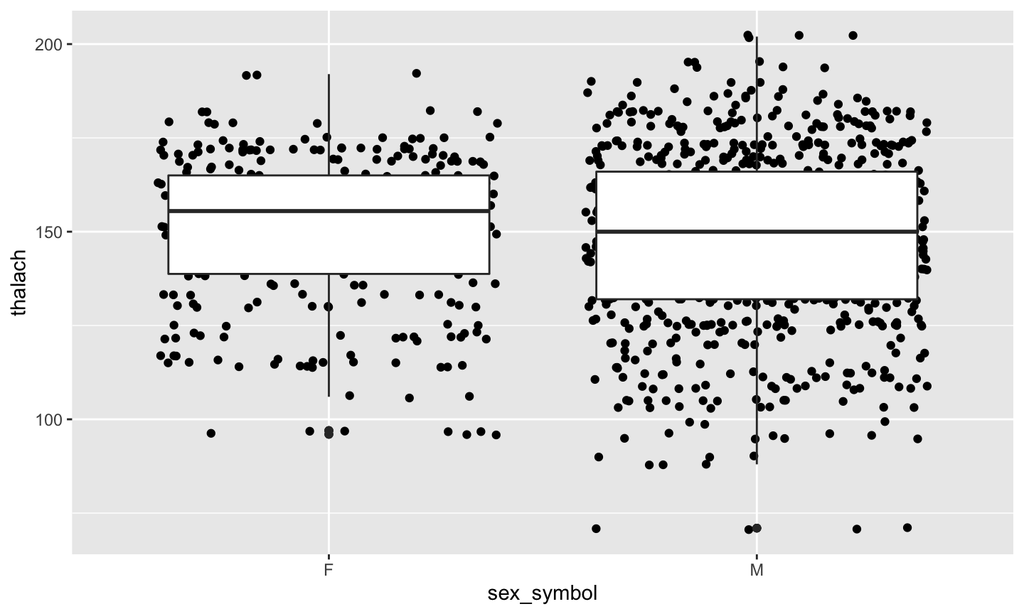

## Global vs Local

You can also set aes values **locally** within the geom function. Doing so will only change the values in that geom

## Global vs Local

ggplot(df_input, aes(x=sex_symbol, y=log(thalach)) +  
geom_jitter() +  
geom_boxplot(aes(color = log(sex_symbol))

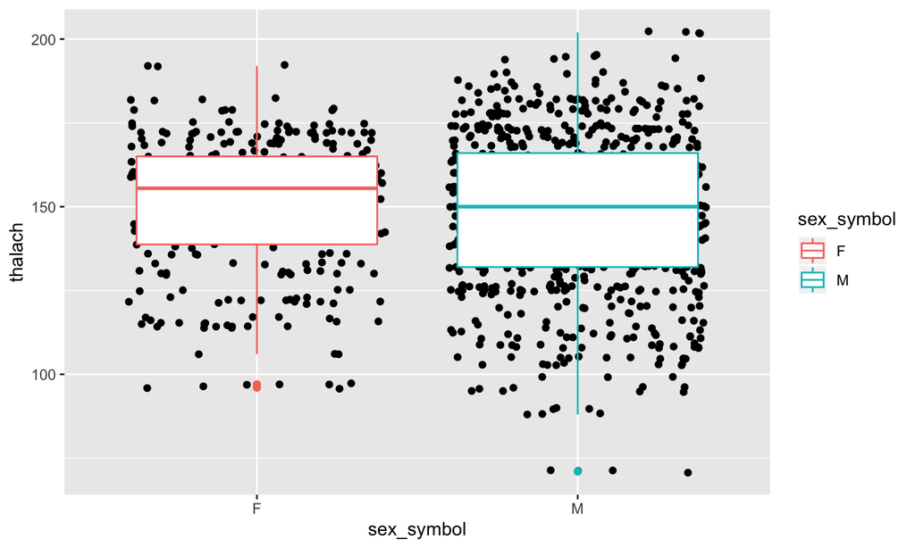

## Global vs Local

Data can also be set locally or globally. For this example, let’s filter our original data first using the `dplyr::filter` function

df_filter <- filter(df_input, thalach > 149)

## Global vs Local

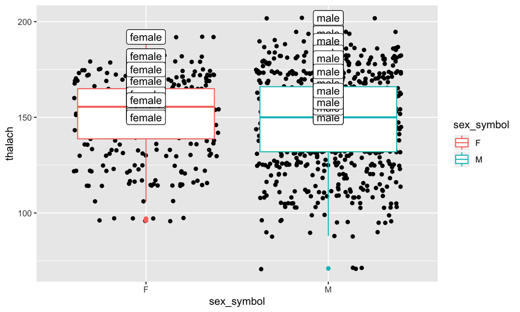

## Labels and Legends

You’ve likely noticed that up until this point ggplot has labeled axes, but not necessarily in a very pleasing manner.  
We can change these settings in our graph using the labs() function.

Let’s start by simply changing the x-axis label ggplot(df_input, aes(x=sex_symbol, y=log(thalach)) +  
geom_jitter() +  
geom_boxplot(aes(color = log(sex_symbol)) +  
geom_label(data=df_filter, aes(label=sex)) +  
labs(x = “Sex_symbol”)

## Labels and Legends

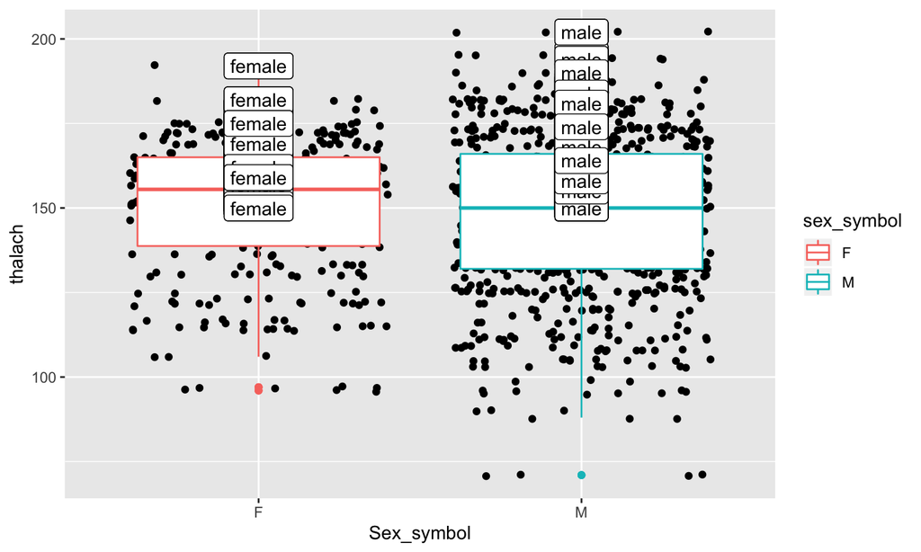

## Labels and Legends

Now, seeing as we have a pretty explanatory legend, we could try to get rid of it. This becomes especially useful when ggplot gives you legends that don’t make sense to show

ggplot(df_input, aes(x=sex_symbol, y=log(thalach)) +  
geom_jitter() +  
geom_boxplot(aes(color = log(sex_symbol)) +  
geom_label(data=df_filter, aes(label=sex)) +  
labs(x = “Sex_symbol”) +  
guides(color = “none”)

## Labels and Legends

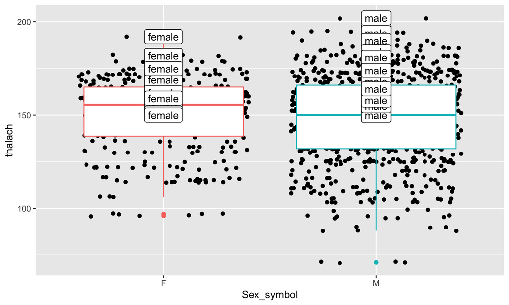

## Faceting

Faceting allows you to create multiple graphs side by side in one panel. Especially useful when you want to see the data together, but not on top of eachother

For example

ggplot(df_input) +  
geom_point(aes(x=sex_symbol, y=log(thalach)) +  
facet_grid(cols = vars(sex))

## Faceting

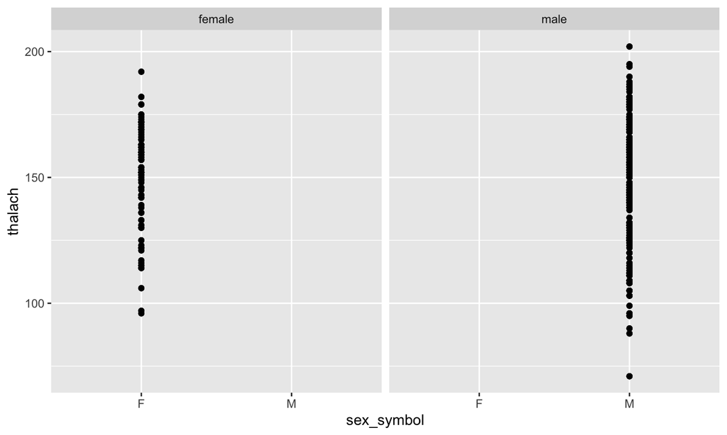

## Coordinate flipping

Coordinate flipping is an especially useful tool when your x-axis includes characters that overlap. Coordinate flipping keeps your mappings and aes the same, but flips coordinates so that your x-axis displays on the Y-axis instead. This allows any names included in the x-axis titles to be read more easily

ggplot(df_input) +  
geom_jitter(aes(x=sex_symbol, y=log(thalach)) +  
coord_flip()

## Coordinate flipping

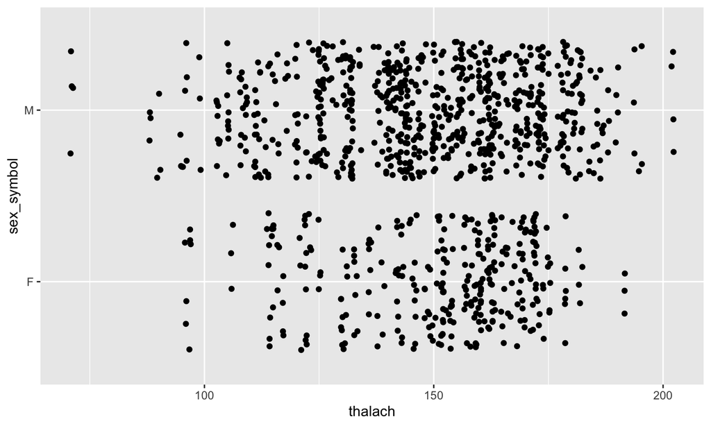

## Themes

You can change almost everything you see on your chart, but a lot of the things you may look to change are part of the “theme”

Here we are going to change some features about our title text

ggplot(df_input, aes(x=sex_symbol, y=log(thalach)) +  
geom_jitter() +  
geom_boxplot(aes(color = log(sex_symbol)) +  
labs(title = “My first plot”) +  
theme( plot.title = element_text(face = “bold”, size = 12) )

## Themes

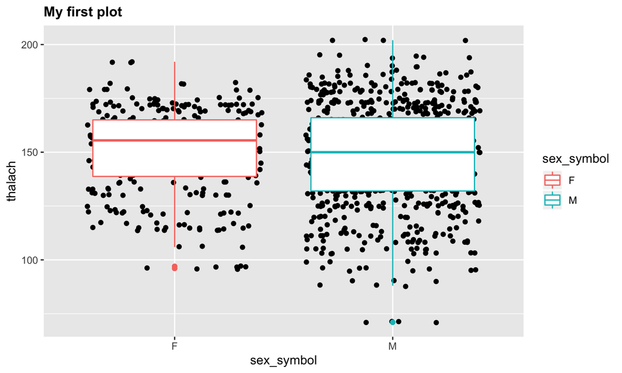

## Themes

Next, let’s change the aesthetics of our legend box

ggplot(df_input, aes(x=sex_symbol, y=log(thalach)) +  
geom_jitter() +  
geom_boxplot(aes(color = log(sex_symbol)) +  
labs(title = “My first plot”) +  
theme( plot.title = element_text(face = “bold”, size = 12), legend.background = element_rect(fill=“gray”, colour=“black”) )

## Themes

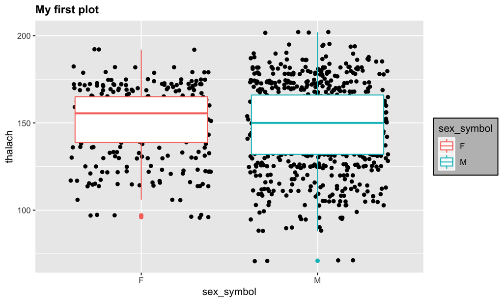

## Themes

Finally, let’s change the legend postion

ggplot(df_input, aes(x=sex_symbol, y=log(thalach)) +  
geom_jitter() +  
geom_boxplot(aes(color = log(sex_symbol)) +  
labs(title = “My first plot”) +  
theme( plot.title = element_text(face = “bold”, size = 12), legend.background = element_rect(fill=“gray”, colour=“black”), legend.position = “bottom” )

## Themes

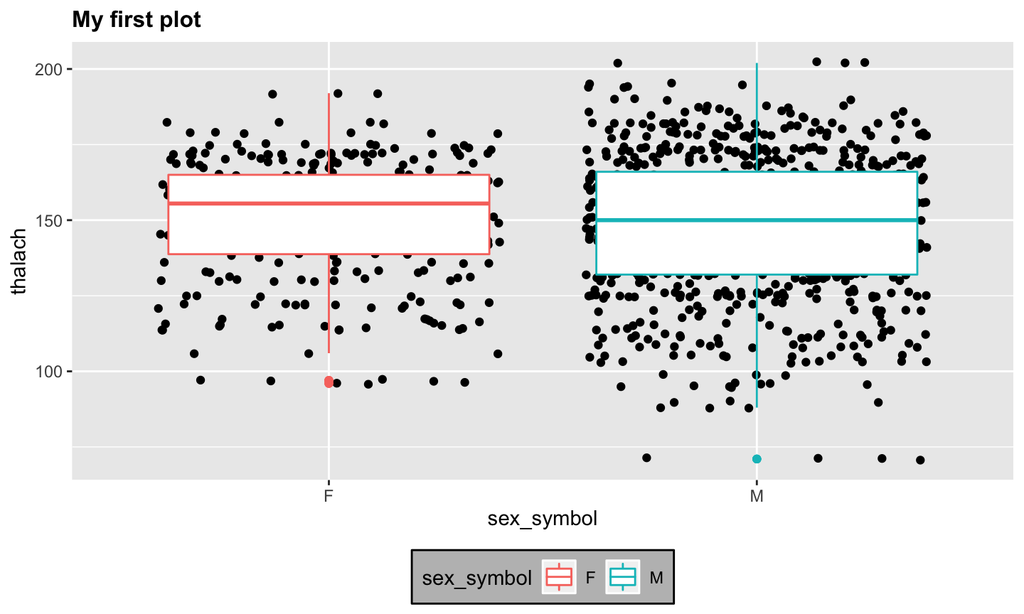

## Themes

Pre-Set themes also exist as an easy way to change the entire theme of your graph quickly. They can also be combined with custome theme settings

ggplot(df_input, aes(x=sex_symbol, y=log(thalach)) +  
geom_jitter() +  
geom_boxplot(aes(color = log(sex_symbol)) +  
labs(title = “My first plot”) +  
theme_bw()

## Themes

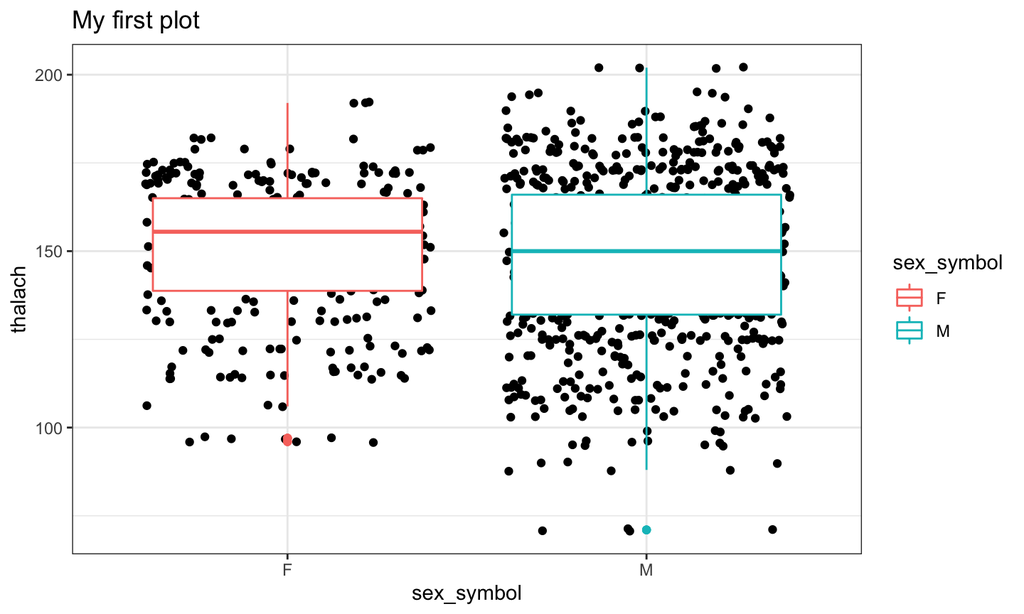

## Saving plots using ggsave

If you make a plot there are a few ways to save it, though the simplest is to use ggsave

ggsave(“ggsaveexample.png”)

You can change the type of file you save or even the size in inches.  
example:

ggsave(“ggsaveexample.pdf”, width = 6, height = 6)

## Saving plots using ggsave

Where does it save??

getwd()

```
## [1] "/Users/akshaybareja/Desktop/R Stuff/Reactivity Testing/reactivity_package/inst/extdata"
```